# R : Shiny - Déployer des applications web avec R

# Chapitre 1 - Créer une première application web

## Application Web

Une application interactive sur Internet est un type de programme accessible via un navigateur web, qui permet aux utilisateurs d’interagir avec le contenu et de recevoir des réponses en temps réel.

Voici ses caractéristiques et composants principaux :

1. **Définition** :
   - Il s’agit d’une application accessible via Internet, généralement via un navigateur web.
   - Elle offre une expérience interactive, où les actions de l’utilisateur déclenchent des réponses immédiates de l’application.
2. **Caractéristiques clés** :
   - **Interface utilisateur interactive** : La partie visible de l’application avec laquelle l’utilisateur interagit directement. Elle peut inclure des éléments tels que des formulaires, des boutons, et des graphiques.
   - **Mise à jour du serveur en fonction des interactions** : Lorsqu’un utilisateur effectue une action (par exemple, cliquer sur un bouton), cette action est traitée par le serveur, qui peut alors mettre à jour les données ou l’interface utilisateur en conséquence.

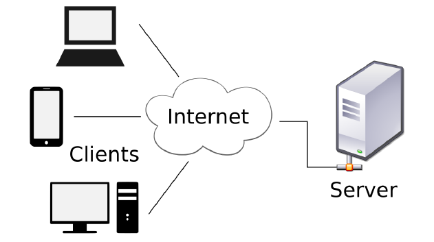

   Représentation d’une application web

3. **Composants** :
   - **Client (interface utilisateur)** : La partie de l’application qui s’exécute dans le navigateur de l’utilisateur. Elle est responsable de présenter les informations à l’utilisateur et de recueillir ses entrées.
   - **Serveur (backend)** : La partie de l’application qui s’exécute sur un serveur distant. Elle gère la logique de l’application, le traitement des données, et les interactions avec les bases de données ou d’autres services.

## Exemples

Voici trois exemples d’applications web :

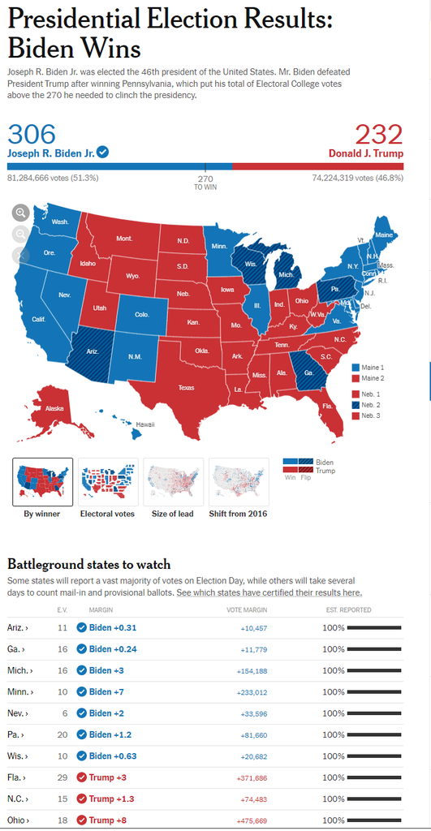

Représentation des élections présidentielles aux USA

[figure not shown]

Suivi des cas de codiv-19 dans le monde

[figure not shown]

Interface Utilisateur de ChatGPT

## Package `Shiny`

```r
# install.packages("shiny")
# library(shiny)
```

La création d’applications web avec R ouvre des portes nouvelles, spécialement pour les data scientists désireux de dépasser les frontières du développement web classique. Ce processus permet de développer à la fois l’interface utilisateur (`ui`) et le backend (`server` ) exclusivement en R, apportant une souplesse remarquable.

Ces applications ne sont pas seulement **réactives** et adaptées aux requêtes, elles sont aussi hautement **interactives**. Les utilisateurs peuvent actualiser les paramètres en direct, enrichissant ainsi leur expérience. Cette autonomie dans l’exploration des résultats accentue **l’engagement** de l’utilisateur.

De plus, la **créativité** est au cœur de cette démarche. Elle permet de concevoir des applications visuellement attrayantes qui améliorent considérablement la présentation et l’analyse des données. L’atout majeur de cette approche réside dans sa capacité à **fusionner performance technique et esthétisme**, ouvrant ainsi des horizons novateurs dans le domaine de la data science.

## Gestion d’une application Shiny

Une application Shiny typique a une structure spécifique avec différents répertoires et fichiers qui servent à différentes fins.

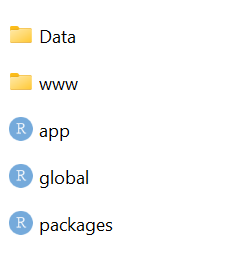

Dossier Crime LA

Par exemple, dans le cadre du développement de l’application `CrimeLA`, il est nécessaire de définir les composants suivants :

### Dossier Data

- **Fonction :** Le dossier ‘data’ est essentiel pour stocker les jeux de données utilisés par votre application.
- **Contenu :** Il peut contenir divers formats de fichiers, tels que CSV, RData, ou tout autre format que R peut lire et importer.
- **Rôle :** Ces données sont cruciales pour le fonctionnement de l’application, car elles constituent la base des analyses et des visualisations.

### Dossier WWW

- **Fonction :** Le dossier ‘www’ est destiné aux fichiers statiques nécessaires pour l’interface de l’application.
- **Contenu :** Il peut inclure des feuilles de style CSS, des scripts JavaScript, et des images.
- **Accès :** Les éléments de ce dossier sont accessibles par le serveur Shiny et peuvent être intégrés dans l’application pour améliorer l’expérience utilisateur et l’interface visuelle.

### app.R

- **Description :** Ce script représente généralement le cœur de l’application Shiny, contenant les scripts UI et Server.

### global.R

- **Fonction :** Le script ‘global’ joue un rôle crucial dans le chargement des configurations.
- **Utilisation :** Il charge des fichiers contenant des paramètres qui influencent le comportement de l’application et sa connexion à d’autres services ou bases de données.

### packages.R

- **Fonction :** Ce script est dédié à la gestion des packages.
- **Rôle :** Les packages sont des ensembles de fonctions supplémentaires qui peuvent être intégrés dans l’application pour étendre ses fonctionnalités ou pour faciliter certaines tâches de programmation.

## Première application Shiny

Le package `shiny` est essentiel, et vous pouvez avoir besoin d’autres packages pour le traitement des données et la visualisation.

Par défaut, il est possible d’éxécuter plusieurs applications d’exemples. En utilisant `runExample("nom_exemple")`, vous pouvez exécuter une série d’exemples intégrés qui démontrent divers aspects du développement d’applications Shiny.

Voici un aperçu de ce que chaque exemple montre :

- **01_hello:** Une application de base montrant un histogramme. C’est une introduction simple à la structure d’une application Shiny.
- **02_text:** Démontre comment afficher des tables et des data frames dans une application Shiny.
- **03_reactivity:** Montre comment utiliser une expression réactive pour mettre à jour l’interface utilisateur en réponse aux entrées de l’utilisateur.
- **04_mpg:** Explique l’utilisation de variables globales dans une application Shiny.
- **05_sliders:** Montre comment utiliser les curseurs (sliders) pour entrer des données dans une application Shiny.
- **06_tabsets:** Démontre l’utilisation de panneaux à onglets pour organiser le contenu.
- **07_widgets:** Montre comment utiliser des widgets d’aide et des boutons de soumission.
- **08_html:** Un exemple d’application Shiny construite à partir de HTML au lieu de R.
- **09_upload:** Un assistant pour télécharger des fichiers dans l’application.
- **10_download:** Un exemple montrant comment configurer le téléchargement de fichiers depuis l’application.
- **11_timer:** (Non spécifié, mais probablement lié à l’utilisation de minuteries ou de fonctions basées sur le temps dans Shiny).

Pour lancer l’exemple `"01_hello"` :

```r
# Charger le package Shiny
library(shiny)

# Exécuter l'exemple intégré "01_hello"
runExample("01_hello")
```

### Créer une app dans R Studio

Pour créer une application de base dans RStudio avec Shiny, suivez ces étapes :

1. **Ouvrir RStudio :** Assurez-vous d’avoir RStudio installé sur votre ordinateur.
2. **Installer et charger le package Shiny :** Si vous n’avez pas déjà installé le package Shiny, vous pouvez le faire en exécutant :

   ```r
   install.packages("shiny")
   ```

   Après l’installation, chargez le package en exécutant :

   ```r
   library(shiny)
   ```

3. **Créer une nouvelle application Shiny :**
   - Allez dans le menu `File > New File > Shiny Web App...`
   - Donnez un nom à votre application.
   - Choisissez l’emplacement où vous souhaitez enregistrer l’application.
   - Sélectionnez le type d’application (par exemple, “Single File (app.R)”).
4. **Rédiger le code de l’application :**
   - RStudio va générer un fichier `app.R` avec un exemple de code.
   - Modifiez ce code pour créer votre propre UI et logique serveur. Par exemple :

   ```r
   ui <- fluidPage(
       titlePanel("Mon Application Shiny"),
       sidebarLayout(
           sidebarPanel(
               sliderInput("slider", "Choisissez un nombre", 1, 100, 50)
           ),
           mainPanel(
               textOutput("result")
           )
       )
   )

   server <- function(input, output) {
       output$result <- renderText({ paste("Vous avez choisi", input$slider) })
   }

   shinyApp(ui = ui, server = server)
   ```

5. **Exécuter l’application :**
   - Cliquez sur le bouton `Run App` dans le coin supérieur droit de l’éditeur de script.
6. **Tester et ajuster :**
   - Votre navigateur web devrait s’ouvrir avec votre application Shiny en cours d’exécution.
   - Testez l’application et apportez les modifications nécessaires dans RStudio.
7. **Développer davantage :**
   - Ajoutez plus de fonctionnalités, des visualisations, ou connectez-vous à des bases de données selon les besoins de votre projet.

En suivant ces étapes, vous pouvez créer et tester votre propre application web interactive en utilisant R Shiny directement dans RStudio.

### Minimum pour afficher une page

Pour afficher une page de base dans une application web avec R Shiny, le code minimum requis se compose de trois parties principales : la définition de l’interface utilisateur (`ui`), la logique du serveur (`server`), et l’exécution de l’application (`shinyApp`).

Voici un exemple de code minimal :

```r
# Charger le package Shiny
library(shiny)

# Définir l'interface utilisateur
ui <- fluidPage(
    # Éléments de l'interface utilisateur peuvent être ajoutés ici
)

# Définir la logique du serveur
server <- function(input, output) {
    # Logique de traitement des données et de réactivité
}

# Exécuter l'application
shinyApp(ui = ui, server = server)
```

Dans cet exemple :

- `fluidPage()` : Crée une page web responsive qui s’adapte à la taille de l’écran de l’utilisateur. Vous pouvez y ajouter divers composants, comme des textes, des graphiques, des tableaux, etc.
- `server <- function(input, output) {}` : C’est ici que vous définirez la logique de votre serveur. Cette fonction traite les entrées de l’utilisateur (`input`) et produit des sorties (`output`).
- `shinyApp(ui, server)` : Cette fonction lance l’application en combinant l’interface utilisateur et la logique serveur que vous avez définies.

Ce code est le **squelette de base pour une application Shiny**. Pour créer une application fonctionnelle, vous ajouterez des éléments à l’interface utilisateur (`ui`) et définirez la logique de traitement des données dans la fonction `server`.

### Control Panels

Les “Control Panels” sont des éléments fondamentaux pour interagir avec l’utilisateur.

Ils se composent généralement de `sidebarPanel()`, qui permet d’ajouter une barre latérale à l’interface. Cette barre latérale est idéale pour inclure divers widgets de contrôle, tels que des curseurs, des sélecteurs d’options, des boutons et bien d’autres éléments interactifs. Ces widgets facilitent la saisie de données et la manipulation des visualisations ou des analyses affichées dans l’application.

En outre, l’utilisation conjointe de `fluidRow()` et `column()` permet de structurer de manière flexible l’agencement de l’interface en lignes et colonnes, offrant ainsi une mise en page réactive et organisée.

1. **sidebarPanel()** :
   - Utilisation : Ajout d’une barre latérale avec des widgets de contrôle (curseurs, sélecteurs, etc.).
   - Exemple : `sidebarPanel("sidebar panel")`.
2. **fluidRow() et column()** :
   - Utilisation : Structuration du layout en lignes et colonnes pour un design responsive.
   - Exemple : Inclus implicitement dans `fluidPage`.

### Création d’une Interface Utilisateur de Base :

```r
# Définition de l'interface utilisateur
ui <- fluidPage(
  titlePanel("title panel"),  # Titre
  sidebarLayout(              # Layout avec barre latérale
    sidebarPanel("sidebar panel"),
    mainPanel("main panel")
  )
)

# Logique du serveur (vide dans cet exemple)
server <- function(input, output) {}

# Lancement de l'application
shinyApp(ui = ui, server = server)
```

### Éléments UI Divers pour le Texte

Les éléments UI pour le texte offrent une variété d’options pour présenter et structurer le contenu.

Les en-têtes, de `h1()` à `h6()`, permettent de créer des titres de différents niveaux, organisant le contenu de manière hiérarchique. Le tag `p()` est utilisé pour ajouter des paragraphes standards, tandis que `a()` crée des liens hypertextes pour connecter à des URL externes.

Pour une séparation visuelle, `br()` insère des sauts de ligne. Les tags `div()` et `span()` sont essentiels pour regrouper et styler du texte, respectivement pour des blocs et des éléments en ligne. `pre()` et `code()` sont spécialement utiles pour afficher du texte préformaté et des lignes de code.

Enfin, pour mettre l’accent, `strong()` et `em()` sont utilisés pour le texte en gras et en italique, respectivement. Ces éléments contribuent à enrichir l’expérience utilisateur en offrant une variété de méthodes pour afficher et structurer le texte dans les applications Shiny.

1. **En-têtes (Headers) :**
   - `h1()` à `h6()` : Créent des en-têtes de différents niveaux pour organiser le contenu hiérarchiquement.
2. **Paragraphe (Paragraph) :**
   - `p()` : Ajoute un paragraphe de texte standard.
3. **Lien hypertexte (Hyperlink) :**
   - `a(href = "https://www.example.com", "Texte")` : Crée un lien vers une URL externe.
4. **Saut de ligne (Line Break) :**
   - `br()` : Insère un saut de ligne.
5. **Division (Division) :**
   - `div()` : Regroupe et style du contenu.
6. **En ligne (Span) :**
   - `span()` : Pour le styling d’éléments inline.
7. **Texte préformaté (Preformatted Text) :**
   - `pre()` : Affiche du texte dans une police à largeur fixe.
8. **Code :**
   - `code()` : Pour afficher des lignes de code.
9. **Image :**
   - `img(src = "path_to_image.jpg", alt = "Description")` : Affiche une image.
10. **Texte en gras (Bold Text) :**
    - `strong()` : Met en évidence un texte en gras.
11. **Texte en italique (Italic Text) :**
    - `em()` : Met en évidence un texte en italique.

```r
# Interface utilisateur avec divers éléments de texte
ui <- fluidPage(
  h1("En-tête de niveau 1"),
  h2("En-tête de niveau 2"),
  p("Ceci est un paragraphe de texte dans Shiny."),
  a(href = "https://www.example.com", "Ceci est un lien hypertexte"),
  br(),
  div("Ceci est une division de texte avec un style uniforme."),
  span("Ceci est une division en ligne de texte avec un style uniforme."),
  pre("Ceci est du texte ‘tel quel’ dans une police à largeur fixe."),
  code("x <- 1:10"),
  img(src = "path_to_image.jpg", alt = "Description de l'image"),
  strong("Ceci est du texte en gras."),
  em("Ceci est du texte en italique.")
)

server <- function(input, output) {}

shinyApp(ui = ui, server = server)
```

## Exercices

#### Exercice 1

Reproduire une interface utilisateur identique à l’image de “My shiny App”.

[figure not shown]

Interface Utilisation à Reproduire

[**Correction exercice 1**](https://github.com/universdesdonnees/R-Shiny/blob/master/exercices/exo1.R)

#### Exercice 2

Définir un canva pour l’application sur les données [CRIMES LA](https://www.kaggle.com/datasets/ishmaelkiptoo/usa-los-angeles-crimes-data-2020-to-2023/data)

# Chapitre 2 - Interaction ui / server

## Interface utilisateur

Dans le contexte du développement web, en particulier avec des frameworks comme Bootstrap utilisés fréquemment dans des applications R Shiny, la largeur d’une page est souvent décrite en termes de “grille”.

Dans Bootstrap, par exemple, **la grille standard est divisée en 12 colonnes**. Cette approche est adoptée pour faciliter la mise en page responsive, permettant aux éléments de s’adapter de manière flexible à différentes tailles d’écran.

Les applications Shiny, utilisées dans le langage de programmation R, sont conçues pour créer des interfaces utilisateur (UI) interactives, principalement axées sur l’analyse et la visualisation de données.

### Layout

- `fluidPage()` : Crée une page responsive
- `fluidRow()` : Organise le contenu en lignes horizontales.
- `column(6, ...)` : Chaque appel à `column()` crée une colonne occupant la moitié de l’espace de la grille (6 sur 12 colonnes). Vous y placez les éléments UI tels que des en-têtes (`h3`) et des paragraphes (`p`).

```r
library(shiny)

ui <- fluidPage(
  titlePanel("Exemple de Fluid Page avec 2 Colonnes"),

  # Utilisation de fluidRow pour organiser les colonnes
  fluidRow(
    # Première colonne
    column(6,
           h3("Colonne 1"),
           p("Contenu de la première colonne")
    ),
    # Deuxième colonne
    column(6,
           h3("Colonne 2"),
           p("Contenu de la deuxième colonne")
    )
  )
)

server <- function(input, output) {}

# shinyApp(ui = ui, server = server)
```

### Widgets d’entrée (Inputs)

Chaque widget d’entrée dans Shiny a une fonction correspondante dans le serveur Shiny pour traiter les entrées de l’utilisateur.

- `textInput()` : Permet à l’utilisateur de saisir du texte.
- `numericInput()` : Pour la saisie de valeurs numériques.
- `sliderInput()` : Un curseur pour sélectionner une gamme de valeurs.
- `selectInput()` : Un menu déroulant pour choisir une option.
- `checkboxInput()` et `checkboxGroupInput()` : Pour effectuer des sélections à l’aide de cases à cocher.
- `radioButtons()` : Pour permettre à l’utilisateur de choisir une option parmi plusieurs.

```r
library(shiny)

# UI definition
ui <- fluidPage(
  # Layout
  titlePanel("Exemple d'Application Shiny"),
  sidebarLayout(
    sidebarPanel(
      # Input widgets
      textInput("text_input", "Entrez du texte :"),
      br(),
      numericInput("num_input", "Entrez un nombre :", 1),
      br(),
      sliderInput("slider_input", "Choisissez une valeur :",
                  min = 1, max = 100, value = 50),
      br(),
      selectInput("select_input", "Choisissez une option :",
                  choices = c("Option 1", "Option 2", "Option 3")),
      br(),
      checkboxGroupInput("checkbox_input", "Sélectionnez :",
                         choices = c("Choix 1", "Choix 2", "Choix 3")),
      br(),
      radioButtons("radio_input", "Sélectionnez une option :",
                   choices = c("Option A", "Option B", "Option C"))
    ),
    mainPanel(
    )
  )
)

# Server logic
server <- function(input, output) {

}

# Run the application
# shinyApp(ui = ui, server = server)
```

**En résumé**

La mise en page, quant à elle, est cruciale pour organiser visuellement les éléments UI et les rendre intuitifs et accessibles pour l’utilisateur.

| Fonction | Widget |
| --- | --- |
| `actionButton` | Bouton d’action |
| `checkboxGroupInput` | Groupe de cases à cocher |
| `checkboxInput` | Une case à cocher |
| `dateInput` | Calendrier pour la sélection de date |
| `dateRangeInput` | Paire de calendriers pour sélectionner une plage de dates |
| `fileInput` | Contrôle de téléchargement de fichier |
| `helpText` | Texte d’aide pouvant être ajouté à un formulaire |
| `numericInput` | Champ pour saisir des nombres |
| `radioButtons` | Ensemble de boutons radio |
| `selectInput` | Boîte avec choix à sélectionner |
| `sliderInput` | Barre de curseur |
| `submitButton` | Bouton de soumission |
| `textInput` | Champ pour saisir du texte |

### **Widgets de Sortie (outputs)**

Grâce aux fonctions d’affichage, les données sont affichées sous différentes formes dans l’UI. Le tableau suivant couvre les types de sorties les plus couramment utilisés dans Shiny.

| Fonction | Description |
| --- | --- |
| `tableOutput()` | Affiche des données sous forme de table. |
| `plotOutput()` | Utilisé pour l’affichage de graphiques. |
| `textOutput()` | Pour afficher du texte simple. |
| `verbatimTextOutput()` | Pour afficher des résultats de code de manière littérale. |
| `imageOutput()` | Pour afficher des images. |
| `dataTableOutput()` | Pour afficher des données sous forme de table interactive (DataTable). |
| `uiOutput()` | Pour afficher des éléments UI générés dynamiquement. |
| `htmlOutput()` | Pour afficher du contenu HTML. |
| `downloadButton()` ou `downloadLink()` | Pour créer un bouton ou un lien de téléchargement. |

Chaque type de sortie est conçu pour afficher un type spécifique de contenu, allant des tables de données et des graphiques aux éléments HTML et aux liens de téléchargement.

#### Exemple 1

```r
library(shiny)

# UI definition
ui <- fluidPage(

  titlePanel("Exemple d'Application Shiny"),

  sidebarLayout(
    sidebarPanel(
      br(),
      textInput("text_input", "Entrez du texte :"),
      br()
    ),
    mainPanel(
      h3("Résultats :"),
      br(),
      # la sortie affichée à l'utilisateur sera sous la forme d'un verbatim
      verbatimTextOutput("text_renvoye_output")
    )
  )
)

# Server logic
server <- function(input, output) {

  # Dans le server est définie une variable d'output "text_renvoye_output"
  # Dans le corps de cette variable, l'input "text_input" est utilisé
  # pour générer un texte concaténé

  output$text_renvoye_output <- renderText({
    paste("Texte entré :", input$text_input)
  })

}

# Run the application
# shinyApp(ui = ui, server = server)
```

#### Exemple 2

```r
library(shiny)

ui <- fluidPage(
  titlePanel("Dynamic UI based on selectInput"),

  sidebarLayout(
    sidebarPanel(
      # A gauche sont définies les options qui sont vues par l'utilisateur.
      # Ces options sont utilisés côté server à partir des variables définies à droite
      selectInput("select_input",
                  "Choisissez une option :",
                  choices = list("Option 1" = "value1",
                                 "Option 2" = "value2",
                                 "Option 3" = "value3"))
    ),
    mainPanel(
      uiOutput("dynamicOutput")
    )
  )
)

server <- function(input, output) {

  # En fonction de l'option choisie (input$select_input),
  # un message spécifique est renvoyé à l'aide d'un switch

  output$dynamicOutput <- renderUI({
    switch(input$select_input,
           "value1" = p("Vous avez sélectionné l'Option 1."),
           "value2" = p("Vous avez sélectionné l'Option 2."),
           "value3" = p("Vous avez sélectionné l'Option 3."),
           p("Sélectionnez une option."))
  })
}

# Run the application
# shinyApp(ui = ui, server = server)
```

## Server

### Les fonctions “render”

Dans les applications Shiny, les fonctions **`render`** sont essentielles pour créer des éléments de sortie réactifs.

Le tableau suivant offre une vue d’ensemble claire des différentes fonctions de rendu disponibles dans Shiny, vous permettant de choisir facilement la fonction appropriée en fonction de vos besoins en matière de visualisation et d’interface utilisateur.

| Fonction | Crée | Utilisation |
| --- | --- | --- |
| `renderDataTable` | Un DataTable | Pour le rendu de tables interactives avancées. |
| `renderImage` | Des images | Pour afficher des images enregistrées sous forme de lien vers un fichier source. |
| `renderPlot` | Des graphiques | Pour le rendu de graphiques (comme ceux créés avec ggplot2 ou les fonctions de graphique de base de R). |
| `renderPrint` | Tout type de sortie imprimée | Pour afficher la sortie des instructions d’impression. |
| `renderTable` | Des data frames, matrices ou autres structures de table | Pour le rendu de tables simples. |
| `renderText` | Des chaînes de caractères | Pour afficher des sorties de texte simples. |
| `renderUI` | Un objet de balisage Shiny ou HTML | Pour le rendu dynamique d’éléments d’interface utilisateur en fonction de la logique côté serveur. |

**En résumé**

Chaque fonction `render`prend une expression R entourée d’accolades **`{}`** comme argument. Cette expression peut aller d’une simple ligne de code à un bloc de code plus complexe.

### Lien entre UI et server

Dans une application Shiny, le lien entre l’interface utilisateur (UI) et le serveur est crucial pour créer des applications interactives.

#### Exemple 1 : Dynamic UI

```r
library(shiny)

ui <- fluidPage(
  titlePanel("Checkbox Input Example"),

  sidebarLayout(
    sidebarPanel(
      # Single checkbox
      checkboxInput("check", "Check to see text", value = FALSE)
    ),
    mainPanel(
      uiOutput("dynamicText")
    )
  )
)
server <- function(input, output) {

  output$dynamicText <- renderUI({
    if(input$check) {
      # Output quand checkbox est sélectionnée
      p("The checkbox is checked!")
    } else {
      # Output quand checkbox n'est pas sélectionnée
      p("The checkbox is not checked.")
    }
  })
}

# Run the application
# shinyApp(ui = ui, server = server)
```

Le lien entre `uiOutput("dynamicText")` dans l’UI et `output$dynamicText` dans le serveur est un exemple parfait de ce mécanisme. Voici comment cela fonctionne :

1. **UI Side - `uiOutput("dynamicText")`:**
   - Dans l’UI, `uiOutput("dynamicText")` est utilisé pour créer un espace réservé dans la `mainPanel` où le contenu dynamique sera affiché.
   - Le `"dynamicText"` est un identifiant unique qui permet de relier cet espace réservé à un élément spécifique généré côté serveur.
   - `uiOutput` est utilisé pour des éléments UI dont le contenu peut varier ou changer en réponse à des actions de l’utilisateur ou à d’autres événements.
2. **Server Side - `output$dynamicText`:**
   - Dans le serveur, `output$dynamicText` correspond à l’identifiant défini dans `uiOutput`.
   - La fonction `renderUI` est affectée à `output$dynamicText`. Cette fonction `renderUI` est réactive et sera réexécutée chaque fois que les entrées dont elle dépend (dans ce cas, `input$check`) changeront.
   - Le contenu généré par `renderUI` est ensuite transmis à l’espace réservé `uiOutput("dynamicText")` dans l’UI.
3. **Interaction et Réactivité :**
   - Lorsque l’utilisateur interagit avec l’application (par exemple, en cochant ou décochant la case), cela change l’état de `input$check`.
   - En réponse à ce changement, le bloc de code à l’intérieur de `renderUI` associé à `output$dynamicText` est réexécuté.
   - Le nouveau contenu généré (dans ce cas, un message indiquant si la case est cochée ou non) est alors envoyé à l’UI et affiché dans la `mainPanel` où `uiOutput("dynamicText")` est placé.

> En résumé, `uiOutput` dans l’UI crée un espace pour les éléments dynamiques, et `output$...` dans le serveur définit ce qui doit être affiché dans cet espace. La fonction `renderUI` sur le serveur permet de générer des éléments UI dynamiques en fonction des entrées de l’utilisateur, assurant ainsi une interaction réactive dans l’application Shiny.

#### Exemple 2 : Utilisation de plusieurs render

```r
library(shiny)
library(DT)

ui <- fluidPage(
  titlePanel("Exemple d'Application avec Divers Widgets de Sortie"),

  sidebarLayout(
    sidebarPanel(
      # Widget d'entrée nécessaire pour 'input$selection'
      textInput("selection", "Entrez votre sélection :")
    ),
    mainPanel(
      # Affichage des résultats des fonctions render*
      dataTableOutput("dataTable"),
      imageOutput("image"),  # Correction ici
      plotOutput("plot"),
      verbatimTextOutput("print"),
      tableOutput("table"),
      textOutput("text"),
      uiOutput("dynamicUI")
    )
  )
)


server <- function(input, output) {
  # Pour renderDataTable
  output$dataTable <- renderDataTable({
    DT::datatable(mtcars)
  })

  # Pour renderImage
  output$image <- renderImage({
    list(src = 'C:/Users/Menyssa/Documents/Cours/R-Shiny/Images/data.png',
         contentType = 'image/png', width = 400, height = 300)
  }, deleteFile = FALSE)

  # Pour renderPlot
  output$plot <- renderPlot({
    plot(cars)
  })

  # Pour renderPrint
  output$print <- renderPrint({
    summary(cars)
  })

  # Pour renderTable
  output$table <- renderTable({
    head(cars)
  })

  # Pour renderText
  output$text <- renderText({
    paste("Sélection actuelle :", input$selection)
  })

  # Pour renderUI
  output$dynamicUI <- renderUI({
    actionButton("button", "Cliquez-moi")
  })
}

# shinyApp(ui = ui, server = server)
```

L’exemple précédent présente une sortie pour afficher différents types de contenus.

**Interface Utilisateur (UI)**

**Serveur**

1. Fonctions `render`:
   - Chaque fonction `render*` correspond à un type de contenu différent et est reliée à un widget de sortie dans l’UI via un identifiant unique (`output$dataTable`, `output$image`, etc.).
   - Les fonctions `render*` traitent les données ou les instructions et produisent le contenu correspondant.
2. Exemples de Contenus Générés :
   - `renderDataTable` génère une table interactive à partir de l’ensemble de données `mtcars`.
   - `renderImage` affiche une image stockée localement.
   - `renderPlot` crée un graphique à partir des données `cars`.
   - `renderPrint` affiche un résumé (output textuel) de l’ensemble de données `cars`.
   - `renderTable` montre les premières lignes des données `cars` sous forme de tableau.
   - `renderText` crée un texte dynamique basé sur la saisie de l’utilisateur (`input$selection`).
   - `renderUI` génère dynamiquement un élément UI, ici un bouton d’action (`actionButton`).

**Fonctionnement Global**

- Lorsqu’un utilisateur interagit avec l’application (par exemple, en saisissant du texte ou en cliquant sur un onglet), les fonctions correspondantes dans le serveur sont déclenchées.
- Ces fonctions `render*` traitent les entrées et mettent à jour les contenus dans les espaces réservés correspondants de l’UI.
- Cela crée une application interactive où les changements côté serveur sont immédiatement reflétés dans l’UI.

## Expression réactive

Les applications Shiny sont appréciées pour leur capacité à interagir rapidement avec l’utilisateur. Cependant, lorsque des calculs lourds sont nécessaires, la performance peut en pâtir.

Heureusement, Shiny offre un moyen d’optimiser ces calculs grâce aux expressions réactives.

### Définition

Une expression réactive dans Shiny est une expression R qui est automatiquement re-calculée lorsque les entrées dont elle dépend changent.

Cela signifie que si vous avez un calcul lourd qui dépend de l’entrée de l’utilisateur, il ne sera recalculé que si cette entrée change, réduisant ainsi le temps de chargement et améliorant l’expérience utilisateur.

### Avantages

- Performance améliorée : Seuls les calculs nécessaires sont effectués.
- Code plus propre et plus facile à maintenir : Sépare la logique de calcul de la logique d’affichage.
- Prévention des calculs redondants : Évite de recalculer les mêmes données.

### Utilisation

Pour utiliser une expression réactive, vous l’encapsulez dans la fonction **`reactive()`**.

Cette fonction retourne un objet réactif qui peut ensuite être utilisé dans d’autres parties de votre application Shiny.

Voici un exemple simple illustrant l’utilisation d’une expression réactive dans une application Shiny :

**!! ATTENTION !! : Le resultat de données réactive s’utilise toujours avec des ()**.

#### Exemple 1 : deux expressions réactives

```r
library(shiny)
library(DT)

ui <- fluidPage(

  titlePanel("Utilisation des Expressions Réactives dans Shiny avec un Jeu de Données"),

  sidebarLayout(
    sidebarPanel(
      sliderInput("number",
                  "Choisissez un nombre:",
                  min = 1,
                  max = 100,
                  value = 50),

      selectInput("cylinders",
                  "Nombre de cylindres :",
                  choices = unique(mtcars$cyl),
                  selected = unique(mtcars$cyl)[1])
    ),
    mainPanel(
      textOutput("result"),
      br(),
      br(),
      DTOutput("tableFiltered")
    )
  )
)

server <- function(input, output) {
  # Expression réactive pour le calcul
  reactiveNumber <- reactive({
    input$number * 2
  })

  # Expression réactive pour filtrer les données
  filteredData <- reactive({
    mtcars[mtcars$cyl == input$cylinders, ]
  })

  output$result <- renderText({
    paste("Le double du nombre est :", reactiveNumber())
  })

  output$tableFiltered <- renderDT({
    filteredData()
  })
}

# shinyApp(ui = ui, server = server)
```

Dans cet exemple :

- Un `selectInput` est ajouté pour permettre à l’utilisateur de sélectionner le nombre de cylindres.
- `filteredData` est une nouvelle expression réactive qui filtre `mtcars` en fonction de la sélection de cylindres.
- `output$tableFiltered` utilise `renderDT` pour afficher le tableau des données filtrées.

#### Exemple 2 : données mtcars

```r
library(shiny)
library(DT)
library(tidyverse)

# Définition de l'interface utilisateur
ui <- fluidPage(
  titlePanel("Exploration des données mtcars"),

  sidebarLayout(
    sidebarPanel(
      helpText("Utilisez les contrôles ci-dessous pour filtrer les données."),

      sliderInput("mpgInput", "Miles per gallon (mpg)",
                  min = min(mtcars$mpg, na.rm = TRUE),
                  max = max(mtcars$mpg, na.rm = TRUE),
                  value = c(min(mtcars$mpg, na.rm = TRUE),
                            max(mtcars$mpg, na.rm = TRUE))),

      selectInput("cylInput", "Nombre de cylindres",
                  choices = unique(mtcars$cyl),
                  selected = unique(mtcars$cyl)[1],
                  multiple = TRUE),

      selectInput("gearInput", "Nombre de vitesses",
                  choices = unique(mtcars$gear),
                  selected = unique(mtcars$gear)[1],
                  multiple = TRUE)
    ),

    mainPanel(
      DTOutput("table"),
      plotOutput("mpgPlot")
    )
  )
)

# Définition de la logique serveur
server <- function(input, output) {

  # Filtrer les données en fonction des entrées
  filteredData <- reactive({
    mtcars %>%
      filter(mpg >= input$mpgInput[1], mpg <= input$mpgInput[2],
             cyl %in% input$cylInput,
             gear %in% input$gearInput)
  })

  # Affichage de la table
  output$table <- renderDT({
    filteredData()
  })

  # Graphique de mpg
  output$mpgPlot <- renderPlot({

    data <- filteredData()

    ggplot(data, aes(x = mpg, fill = factor(cyl))) +
      geom_histogram(binwidth = 1) +
      theme_minimal() +
      labs(title = "Distribution de MPG par Cylindre", x = "MPG",
           fill = "Cylindres")
  })
}

# Lancer l'application
# shinyApp(ui = ui, server = server)
```

## Exercices

### Exercice 3

[**Correction exercice 3**](https://github.com/universdesdonnees/R-Shiny/blob/master/exercices/exo3.R)

### Exercice 4

Objectif : Développer une application simple pour les données `hdv2003` du package (*questionr*). Voici un squelette d’application pour commencer.

### Étape 1 : Installation et Chargement des Packages

```r
# Installation des packages nécessaires
install.packages("shiny")
install.packages("questionr")
install.packages("DT")
install.packages("ggplot2")

# Chargement des packages
library(shiny)
library(questionr)
library(DT)
library(ggplot2)

# Chargement des données
data(hdv2003, package = "questionr")
```

### Étape 2 : Création de l’Interface Utilisateur (UI)

```r
ui <- fluidPage(
    titlePanel("Analyse des Données hdv2003"),

    sidebarLayout(
        sidebarPanel(
            # Widgets pour le filtrage des données
            # (ajouter selectInput, sliderInput, etc. selon les besoins)

            helpText("Utilisez les contrôles pour filtrer les données et visualiser les statistiques.")
        ),
        mainPanel(
            # Affichage des données filtrées
            dataTableOutput("tableData"),

            # Affichage des graphiques
            plotOutput("plot"),

            # Affichage des statistiques
            verbatimTextOutput("stats")
        )
    )
)
```

### Étape 3 : Logique du Serveur

```r
server <- function(input, output) {
    # Logique pour l'affichage des données
    output$tableData <- renderDataTable({
        # Appliquer le filtrage ici si nécessaire
        DT::datatable(hdv2003)
    })

    # Logique pour la visualisation graphique
    output$plot <- renderPlot({
        # Générer le graphique en fonction des entrées utilisateur
        # Par exemple, un histogramme de l'âge
    })

    # Logique pour le résumé statistique
    output$stats <- renderPrint({
        # Calculer et afficher les statistiques en fonction des entrées utilisateur
    })
}
```

### Étape 4 : Lancement de l’Application

```r
shinyApp(ui = ui, server = server)
```

### Conseils

- **Filtrage des Données :** Utilisez les widgets d’entrée pour permettre aux utilisateurs de sélectionner des critères de filtrage. Appliquez ces critères dans `renderDataTable()` et `renderPlot()` pour mettre à jour les visualisations et les tables.
- **Visualisation Graphique :** Utilisez `ggplot2` pour créer des graphiques basés sur les données filtrées. Par exemple, créez un histogramme de l’âge ou un diagramme en barres des catégories socio-professionnelles.
- **Résumé Statistique :** Calculez des statistiques descriptives comme la moyenne, la médiane et l’écart-type pour les données filtrées et affichez-les avec `renderPrint()`.
- **Interactivité Réactive :** Assurez-vous que les modifications des widgets d’entrée déclenchent une mise à jour des tables, des graphiques et des statistiques.
- **Documentation et Aide :** Ajoutez `helpText` ou des commentaires dans l’UI pour guider les utilisateurs sur la manière d’interagir avec l’application.

[**Correction exercice 4**](https://github.com/universdesdonnees/R-Shiny/blob/master/exercices/exo4.R)

# Chapitre 3 - Organisation et Cartographie

## Organisation de l’app web

En suivant ces lignes directrices, votre application Shiny devrait être bien organisée, facile à maintenir et à étendre.

**Script `packages.R`**

Ce script est destiné à charger tous les packages nécessaires pour votre application. Cela aide à maintenir le code organisé et facilite le suivi des dépendances de l’application.

Ici :

**Script `global.R`**

Ce script est utilisé pour définir les variables globales et charger les données qui seront utilisées dans toute l’application. Les variables définies dans `global.R` sont disponibles dans les scripts `ui.R`, `server.R`, et d’autres fichiers R que vous pourriez inclure dans votre application.

Ici :

**Conseils d’Intégration : app.R**

1. **Appel de `global.R` et `packages.R` :** Dans Shiny, ces fichiers sont généralement placés dans le même répertoire que vos scripts `ui.R` et `server.R`. Ils sont chargés automatiquement avant ces scripts, donc toutes les variables et bibliothèques qu’ils contiennent seront disponibles globalement.
2. **Structuration de l’Application :** Assurez-vous que le chemin vers votre fichier CSV est correct et accessible depuis l’endroit où l’application Shiny est exécutée.
3. **Gestion des Packages :** Vérifiez que tous les packages listés dans `packages.R` sont installés. Vous pouvez inclure des instructions `install.packages()` pour les packages manquants, mais commentez-les pour éviter de les réinstaller à chaque fois.

```r
source(file = "../CrimeLA/global.r")
source(file = "../CrimeLA/packages.r")

ui <- fluidPage(

  titlePanel(titre_appli),

  sidebarLayout(
    sidebarPanel(
      selectInput("select_input",
                  "Choisissez une variable :",
                  choices = variables_data)
    ),
    mainPanel(
      tableOutput('variable')
    )
  )
)

server <- function(input, output){

  output$variable <- renderTable({
    tmp <- data %>%
      select(input$select_input)
    head(tmp)
  })
}

# shinyApp(ui = ui, server = server)
```

## Les Onglets

Les onglets sont principalement gérés à travers deux widgets : `tabPanel` et `navlistPanel`. Cette section vous fournira les connaissances et compétences nécessaires pour intégrer ces éléments dans vos applications Shiny, améliorant ainsi la navigation et la structure de votre contenu.

### TabsetPanel

Le `tabsetPanel` est un élément clé pour organiser le contenu dans des onglets horizontaux. Cette méthode de présentation est utile pour afficher différentes sections de contenu sans surcharger l’interface utilisateur.

Voici un exemple de la structure de base d’un `tabsetPanel` :

```r
ui <- fluidPage(
    tabsetPanel(
        tabPanel("Onglet 1",
                 # Contenu de l'onglet 1
        ),
        tabPanel("Onglet 2",
                 # Contenu de l'onglet 2
        )
        # Ajouter plus d'onglets si nécessaire
    )
)
```

Chaque `tabPanel` dans le `tabsetPanel` représente un onglet distinct, permettant aux utilisateurs de basculer entre différents contenus.

### Personnalisation

Comme pour les autres éléments de Shiny, il est possible d’ajouter des icônes à vos `tabPanel` au sein des `tabsetPanel` en utilisant la fonction `icon()`. Les icônes rendent l’interface plus intuitive et visuellement attrayante.

**Exemple Simple avec Onglets Horizontaux** Un exemple simple de `tabsetPanel` peut être le suivant :

```r
ui <- fluidPage(
    tabsetPanel(
        tabPanel("Accueil", icon = icon("home"),
                 # Contenu de l'accueil
        ),
        tabPanel("Profil", icon = icon("user"),
                 # Contenu du profil
        ),
        tabPanel("Paramètres", icon = icon("cog"),
                 # Contenu des paramètres
        )
    )
)

server <- function(input, output, session) {
    # Logique du serveur
}

# shinyApp(ui, server)
```

Dans cet exemple, chaque onglet est clairement identifié par une icône, facilitant la navigation pour l’utilisateur.

#### **Exemple 1 : Avec des widgets de sortie**

Pour une utilisation plus avancée, vous pouvez intégrer du contenu dynamique dans les `tabsetPanel` :

```r
ui <- fluidPage(
    tabsetPanel(
        tabPanel("Graphique",
                 plotOutput("monGraphique")
        ),
        tabPanel("Tableau",
                 DT::dataTableOutput("monTableau")
        ),
        tabPanel("Résumé",
                 verbatimTextOutput("monResume")
        )
    )
)

server <- function(input, output, session) {
    output$monGraphique <- renderPlot({ plot(runif(50)) })
    output$monTableau <- DT::renderDataTable({ DT::datatable(mtcars) })
    output$monResume <- renderPrint({ summary(mtcars) })
}

# shinyApp(ui, server)
```

Dans ce scénario, chaque onglet affiche un type de sortie différent (graphique, tableau, texte), démontrant la polyvalence des `tabsetPanel` pour la présentation de divers types de données.

#### **Exemple 2 : Avec navbarPage**

```r
ui <- fluidPage(
    navbarPage("Titre de l'application",
        tabPanel("Onglet 1",
                 # Contenu de l'onglet 1
        ),
        tabPanel("Onglet 2",
                 # Contenu de l'onglet 2
        )
    )
)
server <- function(input, output){

  output$variable <- renderTable({
    tmp <- data %>%
      select(input$select_input)
    head(tmp)
  })
}

# shinyApp(ui = ui, server = server)
```

Dans cet exemple, `navbarPage` crée une barre de navigation, et chaque `tabPanel` représente un onglet différent dans cette barre.

### NavLists

Le `navlistPanel` permet de créer une liste de navigation latérale, offrant une autre manière de structurer et de naviguer à travers différents contenus.

La structure de base d’un `navlistPanel` est la suivante :

```r
ui <- fluidPage(

    navlistPanel(
        "Titre de la Navigation",
        tabPanel("Onglet 1",
                 # Contenu de l'onglet 1
        ),
        br(),
        br(),
        br(),
        br(),
        tabPanel("Onglet 2",
                 # Contenu de l'onglet 2
        )
    )
)
server <- function(input, output){

}

# shinyApp(ui = ui, server = server)
```

Dans ce cadre, chaque `tabPanel` représente un élément différent dans la liste de navigation.

### Personnalisation

Les icônes peuvent être ajoutées à chaque élément de la liste pour améliorer l’esthétique et la compréhension de l’interface utilisateur. Utilisez la fonction `icon()` pour ajouter des icônes aux titres de vos onglets.

#### **Exemple 1 : Navigation Latérale**

```r
ui <- fluidPage(
    navlistPanel(
        "Navigation",
        tabPanel("Accueil", icon = icon("home"),
                 # Contenu de l'accueil
        ),
        tabPanel("Informations", icon = icon("info-circle"),
                 # Contenu des informations
        )
    )
)

server <- function(input, output, session) {
    # Logique du serveur
}

# shinyApp(ui, server)
```

Dans cet exemple, deux onglets avec des icônes fournissent une navigation intuitive dans l’application.

#### **Exemple 2 : Intégration de TabPanels**

```r
ui <- fluidPage(
    navlistPanel(
        "Navigation Complète",
        tabPanel("Section 1",
                 # Contenu de la section 1
                 tabsetPanel(
                     tabPanel("Sous-section 1",
                              # Contenu de la sous-section 1
                     ),
                     tabPanel("Sous-section 2",
                              # Contenu de la sous-section 2
                     )
                 )
        ),
        tabPanel("Section 2",
                 # Contenu de la section 2
        )
    )
)

server <- function(input, output, session) {
    # Logique du serveur
}

# shinyApp(ui, server)
```

Ici, chaque onglet principal dans le `navlistPanel` contient son propre ensemble de sous-onglets, permettant une organisation complexe et une navigation efficace.

## Afficher des valeurs

**`valueBoxOutput`** est une fonction utilisée pour créer une sortie d’une “Value Box” dans l’interface utilisateur (UI).

Les “Value Boxes” sont souvent utilisées dans les **tableaux de bord Shiny** : `dashboardPage` pour afficher des résumés importants ou des statistiques clés de manière concise et visuellement attrayante. Elles sont particulièrement utiles pour mettre en évidence des chiffres ou des informations critiques, comme des totaux, des moyennes, ou des pourcentages.

Cette fonction est généralement utilisée avec `renderValueBox` sur le côté serveur pour rendre le contenu dynamique.

Voici quelques exemples pour illustrer son utilisation :

#### **Exemple 1 : Affichage d’une valeur**

```r
library(shiny)
library(shinydashboard)

ui <- dashboardPage(
    dashboardHeader(title = "Exemple de Value Box"),
    dashboardSidebar(),
    dashboardBody(
        # Création de l'espace pour la Value Box
        valueBoxOutput("myValueBox")
    )
)


server <- function(input, output) {
    output$myValueBox <- renderValueBox({
        valueBox(
            value = 123,  # La valeur à afficher
            subtitle = "Nombre total de quelque chose",
            icon = icon("check"),  # Icône (facultatif)
            color = "green"  # Couleur de la boîte (facultatif)
        )
    })
}

# shinyApp(ui, server)
```

#### **Exemple 2 : Affichage d’une valeur calculée**

```r
library(shiny)
library(shinydashboard)
library(tidyverse)

ui <- dashboardPage(
    dashboardHeader(title = "Exemple de Value Box"),
    dashboardSidebar(),
    dashboardBody(
        # Création de l'espace pour la Value Box
        valueBoxOutput("hommes")
    )
)

server <- function(input, output) {
    output$hommes <- renderValueBox({
        hommes <- hdv2003 %>%
          filter(sexe == 'Homme') %>%
          nrow()
        valueBox(format(hommes, big.mark = ","),
                 "Nombre d'hommes",
                 icon = icon("mars"))
    })
}
# shinyApp(ui, server)
```

#### **Exemple 3 : Style Personnalisé**

```r
library(shiny)
library(shinydashboard)
library(tidyverse)

ui <- dashboardPage(
    dashboardHeader(title = "Exemple de Value Box"),
    dashboardSidebar(),
    dashboardBody(
        # Création de l'espace pour la Value Box
       valueBoxOutput("progressBox")
    )
)

server <- function(input, output) {
    # Fonction pour simuler la progression
    simulateProgress <- function() {
        Sys.sleep(1)  # Simuler un certain délai
        runif(1, min = 0, max = 100)  # Retourne une valeur aléatoire entre 0 et 100
    }

    output$progressBox <- renderValueBox({
        progress <- simulateProgress()
        valueBox(
            paste(format(round(progress, 0)), "%"),
            "Progression",
            icon = icon("line-chart"),
            color = ifelse(progress < 50, "red", "green")  # Rouge si < 50%, vert sinon
        )
    })
}

# shinyApp(ui, server)
```

## Cartographie avec `leaflet`

*site officiel : https://rstudio.github.io/leaflet/colors.html*

**Leaflet** est une bibliothèque JavaScript open source très populaire, utilisée pour créer des cartes interactives sur le Web. Bien qu’elle soit principalement basée sur JavaScript, elle peut être utilisée dans le langage de programmation R grâce à un package appelé `leaflet` pour R. Voici quelques points clés à connaître sur Leaflet dans le contexte de R :

1. **Création de cartes interactives**: Leaflet vous permet de créer des cartes interactives que vous pouvez intégrer dans des applications web ou des documents R Markdown. Ces cartes peuvent être personnalisées avec différents styles et fonctionnalités.
2. **Facilité d’utilisation**: Même pour les débutants, Leaflet est relativement simple à utiliser en R. Vous pouvez commencer avec quelques lignes de code pour générer une carte de base, puis progressivement ajouter des fonctionnalités plus complexes.
3. **Superpositions et marqueurs**: Vous pouvez ajouter des superpositions à vos cartes, comme des marqueurs, des cercles ou des polygones, pour représenter des données géographiques. Ces éléments peuvent être interactifs, affichant des informations supplémentaires lorsque l’utilisateur clique dessus ou passe la souris dessus.
4. **Intégration avec des données spatiales**: Leaflet pour R fonctionne bien avec des données spatiales. Vous pouvez utiliser des packages comme `sf` (simple features) pour manipuler des données géographiques, puis les visualiser avec Leaflet.
5. **Personnalisation**: Vous avez la possibilité de personnaliser l’apparence de votre carte avec différents styles de tuiles (par exemple, OpenStreetMap, Mapbox) et d’ajouter des fonctionnalités comme des couches de contrôle, des légendes, et plus encore.

Pour commencer avec Leaflet en R, vous devez d’abord installer et charger le package `leaflet`. Ensuite, vous pouvez utiliser des fonctions comme `leaflet()` pour créer une carte et `addTiles()` pour ajouter des tuiles de fond. De là, vous pouvez explorer d’autres fonctions pour ajouter des marqueurs, des couches, etc.

### Installer et charger le package leaflet

Voici un exemple de script pour génèrer une carte interactive sur laquelle vous pouvez zoomer et vous déplacer

### Créer une carte de base

```r
library(leaflet)

map <- leaflet() %>%
  addTiles()  # Ajoute les tuiles de base d'OpenStreetMap
```

Ici, une carte de base est créée avec `leaflet()` et des tuiles par défaut (généralement d’OpenStreetMap) sont ajoutées avec `addTiles()`. Le résultat est stocké dans la variable `map`.

### Ajouter un marqueur

```r
library(leaflet)

map_point <- leaflet() %>%
  addTiles() %>%
  addMarkers(lng = -0.09, lat = 51.50, popup = "The marker is placed at London")
```

Cette ligne ajoute un marqueur sur la carte. Le marqueur est placé à Londres (longitude -0.09, latitude 51.50), et un texte popup s’affiche lorsque vous cliquez sur le marqueur (“The marker is placed at London”).

[interactive chart not shown]

### Changer le fond de carte

Dans la bibliothèque Leaflet pour R, les “providers” font référence aux différents fournisseurs de tuiles qui offrent divers styles de cartes.

Voici une liste de certains des fournisseurs de tuiles les plus couramment utilisés disponibles via `leaflet`:

1. **OpenStreetMap**:
   - `OpenStreetMap.Mapnik`
   - `OpenStreetMap.BlackAndWhite`
   - `OpenStreetMap.DE`
   - `OpenStreetMap.France`
   - `OpenStreetMap.HOT`
2. **Stamen**:
   - `Stamen.Toner`
   - `Stamen.TonerLite`
   - `Stamen.Watercolor`
   - `Stamen.Terrain`
   - `Stamen.TerrainBackground`
   - `Stamen.TopOSMRelief`
3. **Esri**:
   - `Esri.WorldStreetMap`
   - `Esri.DeLorme`
   - `Esri.WorldTopoMap`
   - `Esri.WorldImagery`
   - `Esri.WorldTerrain`
   - `Esri.WorldShadedRelief`
   - `Esri.WorldPhysical`
   - `Esri.OceanBasemap`
   - `Esri.NatGeoWorldMap`
   - `Esri.WorldGrayCanvas`
4. **CartoDB**:
   - `CartoDB.Positron`
   - `CartoDB.PositronNoLabels`
   - `CartoDB.PositronOnlyLabels`
   - `CartoDB.DarkMatter`
   - `CartoDB.DarkMatterNoLabels`
   - `CartoDB.DarkMatterOnlyLabels`
   - `CartoDB.Voyager`
   - `CartoDB.VoyagerNoLabels`
   - `CartoDB.VoyagerOnlyLabels`
   - `CartoDB.VoyagerLabelsUnder`
5. **Thunderforest**:
   - `Thunderforest.OpenCycleMap`
   - `Thunderforest.Transport`
   - `Thunderforest.TransportDark`
   - `Thunderforest.SpinalMap`
   - `Thunderforest.Landscape`
   - `Thunderforest.Outdoors`
   - `Thunderforest.Pioneer`

Pour utiliser ces providers dans votre carte Leaflet, vous utilisez généralement la syntaxe `addProviderTiles(providers$ProviderName)`, où `ProviderName` est remplacé par l’un des noms de fournisseurs listés ci-dessus.

Il est important de noter que certains fournisseurs peuvent avoir des restrictions d’utilisation ou nécessiter des clés API, comme ceux de Mapbox. Assurez-vous de consulter la documentation ou le site Web du fournisseur pour des informations plus détaillées sur l’utilisation et les restrictions.

```r
map_point_cf <- map_point %>%
  addProviderTiles(providers$CartoDB.Positron)
```

[interactive chart not shown]

Ici, le style de la carte est changé en utilisant une tuile différente fournie par `CartoDB.Positron`, donnant à la carte un aspect visuel différent.

### Ajouter des marqueurs supplémentaires

```r
data <- data.frame(
  lng = c(-0.09, -0.11, -0.12),
  lat = c(51.50, 51.52, 51.48),
  label = c("Point 1", "Point 2", "Point 3")
)

map <- map %>%
  addMarkers(data = data, ~lng, ~lat, popup = ~label)
```

Ces lignes ajoutent des marqueurs supplémentaires à la carte en utilisant les données du `data.frame` créé précédemment. Chaque marqueur affiche le texte correspondant dans `label` lorsqu’on clique dessus.

[interactive chart not shown]

### Autres exemples

#### Paris

```r
Paris <- c(2.351462,48.8567)
map_paris <- leaflet() %>%
  setView(lng = Paris[1], lat = Paris[2], zoom = 12) %>%
  addTiles() %>%
  addProviderTiles(providers$Stamen.TonerLite)
```

[interactive chart not shown]

#### IA School Toulouse

1. **Création du Contenu du Popup** :

```r
content <- paste(sep = "<br/>", ...)
```

Cette portion crée une chaîne HTML `content` qui sera utilisée dans le popup. Elle contient un lien vers le site web de l’IA School à Toulouse, ainsi que l’adresse de l’école, formatée avec des balises HTML pour une meilleure présentation.

2. **Création et Configuration de la Carte avec Popup** :

```r
leaflet() %>%
  addTiles() %>%
  addPopups(...)
```

```r
content <- paste(sep = "<br/>",
                 "<b><a href='https://www.intelligence-artificielle-school.com/ecole/nos-campus/toulouse/'>IA School - Toulouse</a></b>",
                 "2 Bd de Strasbourg",
                 "31000 Toulouse"
)

map_ia <- leaflet() %>%
  addTiles() %>%
  addPopups(1.4485130539619018, 43.60676750775245,
            content, options = popupOptions(closeButton = FALSE)
  ) %>%
  addProviderTiles(providers$Stamen.TonerLite)
```

[interactive chart not shown]

Une nouvelle carte est créée, des tuiles de base sont ajoutées, et un popup est placé aux coordonnées spécifiées (Toulouse, France). Le popup affiche le contenu HTML défini précédemment. L’option `closeButton = FALSE` signifie que le popup n’aura pas de bouton de fermeture.

Dans les deux cas, ces blocs de code illustrent comment créer des cartes interactives en R avec le package `leaflet`, en se concentrant sur des emplacements spécifiques (Paris et Toulouse) et en utilisant des fonctionnalités telles que les vues personnalisées, les styles de tuiles et les popups.

## [Leaflet dans Rshiny](https://rstudio.github.io/leaflet/shiny.html)

Le package Leaflet inclut des fonctionnalités puissantes et pratiques pour l’intégration avec les applications Shiny.

La plupart des widgets de sortie Shiny sont incorporés dans une application en incluant une sortie (par exemple, `plotOutput`) pour le widget dans la définition de l’interface utilisateur, et en utilisant une fonction de rendu (par exemple, `renderPlot`) dans la fonction serveur.

Les cartes Leaflet ne sont pas différentes ; dans l’interface utilisateur, vous appelez `leafletOutput`, et du côté serveur, vous attribuez un appel à `renderLeaflet` à la sortie. À l’intérieur de l’expression `renderLeaflet`, vous retournez un objet de carte Leaflet.

```r
library(shiny)
library(leaflet)

r_colors <- rgb(t(col2rgb(colors()) / 255))
names(r_colors) <- colors()

ui <- fluidPage(
  leafletOutput("mymap"),
  p(),
  actionButton("recalc", "Nouveaux points")
)

server <- function(input, output, session) {

  points <- eventReactive(input$recalc, {
    cbind(rnorm(40) * 2 + 13, rnorm(40) + 48)
  }, ignoreNULL = FALSE)

  output$mymap <- renderLeaflet({
    leaflet() %>%
      addProviderTiles(providers$Stadia.StamenTonerLite,
        options = providerTileOptions(noWrap = TRUE)
      ) %>%
      addMarkers(data = points())
  })
}

shinyApp(ui, server)
```

Dans cet exemple, une application Shiny est créée avec une carte Leaflet interactive. Les points sur la carte sont recalculés et mis à jour à chaque fois que l’utilisateur clique sur le bouton “Nouveaux points”.

## Exercice

### Exercice 5

Créer une application R Shiny complète pour cette analyse :

**“Beer or Coffee in London - Tough Choice? No more!”**

https://www.kaggle.com/code/gpreda/beer-or-coffee-in-london-tough-choice-no-more

# Projet : Analyse des données CRIME LA

Créer un projet pour une application web Shiny basée sur un tableau de bord de données criminelles à Los Angeles.

Le projet sera organisé en plusieurs étapes, en intégrant les éléments de réactivité, une carte, des onglets, et des ValueBoxes.

Pour mener à bien votre projet de développement d’une application Shiny sur les données de criminalité à Los Angeles, voici un plan d’action détaillé répondant aux exigences énoncées :

### 1. Développement

#### Interface Utilisateur :

- **Conception** : Utilisez `shinydashboard` pour une interface claire et professionnelle.
- **Visualisation** : Intégrez `ggplot2` pour les graphiques et `leaflet` pour les cartes.
- **Filtrage des Données** : Ajoutez des widgets comme `selectInput`, `dateRangeInput` pour filtrer par type de crime, date, etc.
- **Statistiques Résumées** : Utilisez `DT::datatable()` pour afficher les données et `summary()` pour les statistiques.

### 2. **Données**

Ne pas inclure le fichier de données dans le dépôt GitHub. Fournir des instructions sur comment charger le jeu de données dans le fichier README.

### 3. Dépôt GitHub

- **Création du Dépôt** : Créer un dépôt public sur GitHub.
- **Fichier README** : Inclure des instructions d’installation, un aperçu du projet, et des détails sur les fonctionnalités.
- **Code Source** : Déposer le code de l’application et les scripts nécessaires.

#### Exemple de Structure de Dépôt

```
/mon-application-shiny
  /www
  app.R
  global.R
  README.md
  .gitignore
```

### 4. Documentation

- **Documentation** : Commentez le code pour expliquer les fonctions et les choix logiques.
- **Commentaires** : Ajoutez des commentaires aux sections clés pour faciliter la compréhension.

### 5. Soumission

- **Lien GitHub** : Assurez-vous que le lien est accessible et que le dépôt est public.
- **Rapport** : Inclure un rapport dans le dépôt GitHub ou en format PDF décrivant les choix de conception et les défis.

### Critères d’Évaluation

Assurez-vous que votre application répond aux critères d’évaluation mentionnés, en mettant l’accent sur la fonctionnalité, l’utilisabilité, la qualité du code, l’analyse des données, et l’utilisation efficace de GitHub.

### Conseils Supplémentaires

- **Testez** votre application en profondeur pour vous assurer qu’elle fonctionne sans erreur.
- **Révisez** votre application en fonction des retours des utilisateurs ou des collègues si possible.
- **Mettez en Évidence** les fonctionnalités uniques ou les analyses intéressantes dans votre rapport.

En suivant ce plan d’action, vous serez en mesure de créer une application Shiny bien conçue et documentée, tout en respectant les exigences éthiques et les meilleures pratiques de développement.

Bonne chance avec votre projet !

# Projet : Visualisation des Velib à Paris

Ce projet vise à développer une application Shiny interactive qui étend le travail précédemment effectué par les étudiants de Bachelor sur la visualisation en temps réel des stations Vélib à Paris

## Instructions

Vous êtes chargés d’intégrer, d’améliorer et d’optimiser ces visualisations dans une application R Shiny dynamique et conviviale.

Vous devez créer 3 onglets qui permettent aux utilisateurs de :

1. Visualiser en temps réel les informations (disponibilité des vélos, capacité des stations, etc.) sur les stations Vélib à Paris sous la forme d’une carte Leaflet
2. Afficher les stations par arrondissement et afficher les informations sous forme d’une table.
3. Créer une fonction qui permet d’entrer une adresse et de visualiser les stations velibs les plus proches (rayon de 500 mètres).

## Code initial : Paris

```r
library(tidyverse)
library(leaflet)
library(ggmap)
library(plotly)
library(leaflet)


url <- "https://opendata.paris.fr/api/explore/v2.1/catalog/datasets/velib-disponibilite-en-temps-reel/exports/csv?lang=fr&timezone=Europe%2FBerlin&use_labels=true&delimiter=%3B"

destfile <- tempfile(fileext = ".csv")

download.file(url, destfile)

velib_data <- read_delim(destfile, delim = ";", escape_double = FALSE, trim_ws = TRUE)
velib_sep <- separate(velib_data, "Coordonnées géographiques", into = c("latitude", "longitude"), sep = ",\\s*", convert = TRUE)


carte_velos <- leaflet(data = velib_sep) %>%
  addTiles() %>%
  setView(lng = 2.3522, lat = 48.8566, zoom = 12) %>%
  addMarkers(
    lng = ~longitude,
    lat = ~latitude,
    popup = ~paste(
      "<b>Station Velib:</b>",
      "<span style='font-size: 17px; text-decoration: underline;'>", `Nom station`, "</span>",
      "<br><b>Nombre de vélos disponibles:</b>",
      "<span style='font-size: 17px;'>", `Nombre total vélos disponibles`, "</span>",
      "<br><b>Nombre de bornes libres:</b>",
      "<span style='font-size: 17px;'>", `Nombre bornettes libres`, "</span>",
      "<br><b>Vélos mécaniques disponibles:</b>",
      "<span style='font-size: 17px;'>", `Vélos mécaniques disponibles`, "</span>",
      "<br><b>Vélos électriques disponibles:</b>",
      "<span style='font-size: 17px;'>", `Vélos électriques disponibles`, "</span>"
    ),
    clusterOptions = markerClusterOptions())


carte_velos
```

# Chapitre 4. Personnalisation de l’application

## Shinythemes

La personnalisation d’une application Shiny avec `shinythemes` est un processus qui combine l’utilisation de thèmes prédéfinis, la personnalisation CSS et une intégration soignée avec les composants Shiny.

Cela peut améliorer considérablement l’apparence et l’expérience utilisateur de votre application Shiny.

### Installation et chargement

Tout d’abord, vous devez installer et charger le package `shinythemes`.

```r
install.packages("shinythemes")
library("shinythemes")
```

### **Utilisation de thèmes prédéfinis**

[shinythemes](https://rstudio.github.io/shinythemes/) offre une variété de thèmes Bootstrap prédéfinis. Vous pouvez appliquer ces thèmes à votre application Shiny en utilisant la fonction `theme` dans l’appel à `fluidPage` ou `navbarPage`. Par exemple, `fluidPage(theme = shinytheme("flatly"), ...)`. Quelques thèmes populaires incluent “flatly”, “darkly”, “cerulean”, entre autres.

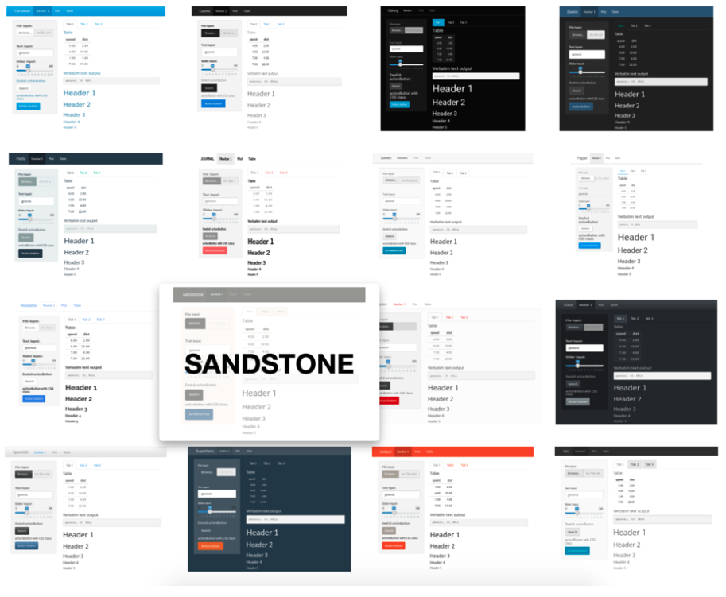

Themes prédéfinis

```r
library(shiny)
library(shinythemes)

# Define UI for application that draws a histogram
ui <- fluidPage(
    theme = shinytheme("united"),
    # Application title
    titlePanel("Old Faithful Geyser Data"),

    # Sidebar with a slider input for number of bins
    sidebarLayout(
        sidebarPanel(
            sliderInput("bins",
                        "Number of bins:",
                        min = 1,
                        max = 50,
                        value = 30)
        ),

        # Show a plot of the generated distribution
        mainPanel(
           plotOutput("distPlot")
        )
    )
)

# Define server logic required to draw a histogram
server <- function(input, output) {

    output$distPlot <- renderPlot({
        # generate bins based on input$bins from ui.R
        x    <- faithful[, 2]
        bins <- seq(min(x), max(x), length.out = input$bins + 1)

        # draw the histogram with the specified number of bins
        hist(x, breaks = bins, col = 'darkgray', border = 'white',
             xlab = 'Waiting time to next eruption (in mins)',
             main = 'Histogram of waiting times')
    })
}

# Run the application
# shinyApp(ui = ui, server = server)
```

```r
ui <- fluidPage(
    theme = shinytheme("yeti"),  # Application du thème Yeti
    navbarPage("Shiny avec Yeti",
        tabPanel("Tab 1",
            h2("Contenu du Tab 1")
        ),
        tabPanel("Tab 2",
            h2("Contenu du Tab 2")
        )
    )
)

server <- function(input, output, session) {}

# shinyApp(ui, server)
```

On peut laisser le choix à l’utilisateur de sélectionner le thème qu’il souhaite.

```r
ui = fluidPage(
  shinythemes::themeSelector(),  # <--- Add this somewhere in the UI
  sidebarPanel(
    textInput("txt", "Text input:", "text here"),
    sliderInput("slider", "Slider input:", 1, 100, 30),
    actionButton("action", "Button"),
    actionButton("action2", "Button2", class = "btn-primary")
  ),
  mainPanel(
    tabsetPanel(
      tabPanel("Tab 1"),
      tabPanel("Tab 2")
    )
  )
)
server = function(input, output) {}

# shinyApp(ui, server)
```

## Utilisation des tags

Dans Shiny, les `tags` sont utilisés pour ajouter des éléments HTML à votre interface utilisateur (UI).

La fonction `tags` dans Shiny est un moyen pratique d’incorporer des éléments HTML standards, comme des divs, des scripts, des styles, des liens, des en-têtes, et plus encore.

Voici comment vous pouvez les utiliser :

### Structure de Base

La structure de base pour utiliser `tags` est la suivante :

```r
tags$nom_de_tag(attributs, "Contenu")
```

- `nom_de_tag` : C’est le nom de l’élément HTML que vous souhaitez ajouter (par exemple, `div`, `h1`, `p`, `a`, etc.).
- `attributs` : Cela inclut des attributs HTML comme `class`, `style`, `href` pour les liens, etc.

`"Contenu"` : C’est le contenu à afficher dans l’élément HTML.

```r
ui <- fluidPage(
    tags$h1("Bienvenue sur Mon Application Shiny!"),
    tags$p("Ceci est un exemple d'utilisation des tags pour ajouter des éléments HTML."),
    tags$a(href = "https://www.exemple.com", "Visitez Exemple.com")
)
```

## Personnalisation avec CSS

Ici, nous allons personnaliser l’apparence des boutons en plus d’appliquer le thème `sandstone`.

### Dans l’UI

- **Utiliser theme, tags et CSS** :

```r
library(shiny)
library(shinythemes)

ui <- fluidPage(
    theme = shinytheme("sandstone"),  # Application du thème Sandstone
    tags$head(
        tags$style(HTML("
            .btn {
                background-color: navy;
                color: white;
            }
            .btn:hover {
                background-color: skyblue;
            }
        "))
    ),
    actionButton("myButton", "Cliquez Moi")
)

server <- function(input, output, session) {}

shinyApp(ui, server)
```

- **Utiliser `div` pour organiser l’UI avec des classes CSS** :

  ```r
  ui <- fluidPage(
    tags$div(class = "ma-classe-css",         sliderInput("slider", "Sélectionnez une Valeur", 1, 100, 50)     ),
    tags$div(class = "une-autre-classe",         plotOutput("monPlot"))
    )
  ```

- **Ajouter du style CSS ou des scripts JavaScript** :

  ```r
  ui <- fluidPage(
      tags$head(
          tags$style(HTML("
              h1 { color: blue; }
              .ma-classe-css { font-weight: bold; }
          ")),
          tags$script("alert('Bienvenue sur mon application Shiny!');")
      ),
      tags$h1("En-tête avec Style"),
      tags$div(class = "ma-classe-css", "Texte avec style personnalisé")
  )
  ```

### Importer un fichier CSS

Supposons que vous ayez créé un fichier CSS nommé `custom.css` pour définir votre propre style. Vous pouvez l’inclure dans votre application Shiny.

```r
library(shiny)
library(shinythemes)

ui <- fluidPage(
    theme = shinytheme("lumen"),  # Application du thème Lumen
    tags$head(
        tags$link(rel = "stylesheet", type = "text/css", href = "custom.css")  # Lien vers le fichier CSS personnalisé
    ),
    headerPanel("Application avec CSS Personnalisé"),
    sidebarLayout(
        sidebarPanel(
            sliderInput("slider", "Choisissez une valeur", 1, 100, 50)
        ),
        mainPanel(
            plotOutput("plot")
        )
    )
)

server <- function(input, output, session) {
    output$plot <- renderPlot({
        hist(rnorm(input$slider))
    })
}

# shinyApp(ui, server)
```

Dans cet exemple, **`custom.css`** devrait être placé dans le même répertoire que votre script Shiny ou dans un sous-dossier nommé **`www`**.

## Exemple : Création de box info personnalisée

```r
library(shiny)
library(shinydashboard)

# Données exemple
info_ligne <- data.frame(
  LIGNE = c("L1", "L2"),
  annee_ouv = c(1900, 1905),
  n_station = c(20, 25),
  tps_parcours = c(30, 35),
  longueur = c(10, 15),
  dist_moy_arret = c(500, 600),
  tps_marche_2_arret = c(5, 6),
  auto = c("Oui", "Non"),
  nb_rames = c(40, 50),
  nb_commune_desservi = c(5, 6),
  arrdsmt_pcpal = c("3e", "4e")
)

# Fonction pour les couleurs (exemple simple)
colligne <- function() {
  "#FF5733"
}

# Fonction box_icon
box_icon <- function(...) {
  tags$div(
    class = "list-group",
    lapply(list(...), function(x) {
      tags$span(
        class = "list-group-item",
        tags$span(icon(x$icon, class = "fa-fw fa-lg"),
                  style = paste("color:", x$col)),
        HTML("&nbsp;"),
        x$text
      )
    })
  )
}

# UI
ui <- fluidPage(
  fluidRow(
    box(
      title = "Informations Lignes : Le saviez-vous ?",
      status = "primary",
      width = 4,
      uiOutput("info_ligne")
    )
  )
)

# Server
server <- function(input, output) {
  output$info_ligne <- renderUI({
    ligne_choisie <- "L1"  # Exemple fixe pour le test

    box_icon(
      list(icon = "calendar", col = colligne(),
           text = paste("Ouverture de la première ligne en", info_ligne$annee_ouv[info_ligne$LIGNE == ligne_choisie])
      )
      # ... autres éléments ...
    )
  })
}

# Lancement de l'application
# shinyApp(ui, server)
```

## Exercice

Reproduire ce tableau issus de l’application suivante : [ratp-traffic](https://shinyapps.dreamrs.fr/ratp-traffic/)

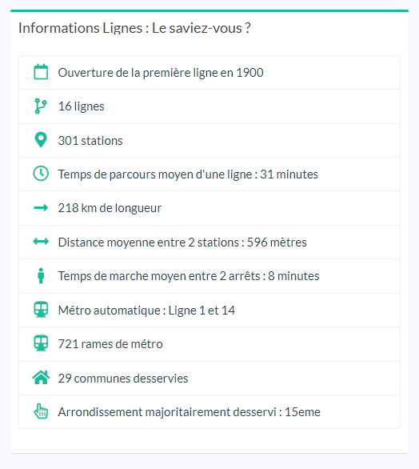

Image à reproduire

Code pour le header :

.box.box-primary { border-top-color: #18bc9c !important; }

# Projet : Shopper Sentiments reviews (3/ 4 personnes)

## Objectif

Créer une application Shiny interactive pour analyser et visualiser les données des sentiments des clients issues de l’ensemble de données disponible sur Kaggle ([Shopper Sentiments](https://www.kaggle.com/datasets/nelgiriyewithana/shoppersentiments/data)).

## Données

Utilisez l’ensemble de données “Shopper Sentiments” qui contient diverses informations sur les avis des clients, comme les évaluations, les commentaires, et d’autres attributs pertinents.

## Fonctionnalités Requises

1. **Importation et Nettoyage des Données** :
   - Permettre à l’utilisateur d’importer le jeu de données.
   - Inclure des options pour nettoyer et prétraiter les données (gestion des valeurs manquantes, normalisation, etc.).
2. **Visualisation des Données** :
   - Créer des graphiques interactifs pour visualiser les données (par exemple, des histogrammes, des graphiques en barres, des boîtes à moustaches).
   - Permettre à l’utilisateur de sélectionner des variables spécifiques pour la visualisation.
3. **Analyse des Sentiments** :
   - Analyser les sentiments des commentaires des clients (positifs, négatifs, neutres).
   - Afficher les résultats sous forme de graphiques ou de tableaux récapitulatifs.
4. **Filtrage et Recherche** :
   - Permettre aux utilisateurs de filtrer les données en fonction de critères spécifiques (par exemple, plage de dates, évaluations, etc.).
   - Inclure une fonction de recherche pour trouver des avis spécifiques.
5. **Thèmes et Personnalisation** :
   - Utiliser `shinythemes` pour permettre à l’utilisateur de changer le thème visuel de l’application.
   - Offrir des options de personnalisation de l’interface, comme le choix des couleurs ou la disposition des éléments.
6. **Tableau de Bord et Navigation** :
   - Créer un tableau de bord intuitif avec une navigation facile entre différentes sections de l’application.
   - Organiser l’application en onglets ou panneaux pour une meilleure clarté.
7. **Rapports et Exportation** :
   - Donner la possibilité de générer des rapports récapitulatifs basés sur les analyses effectuées.
   - Permettre l’exportation des graphiques et des tableaux en différents formats (PDF, PNG, CSV).

#### Livrables

- Code source de l’application Shiny sur GitHub
- Présentation de 15 min

#### Évaluation

Les projets seront évalués sur les critères suivants : - Fonctionnalité : Respect des exigences et fonctionnalité globale. - Qualité du code : Propreté, organisation et documentation. - Créativité et innovation dans l’approche de visualisation et d’analyse des données.